# Power Analysis

I performed power analysis for my dissertation project (Studies 2 and 3). Study 1 did not have a power analysis since I used pre-existing datasets.

```r
library(pwr)
library(psych) # fisherz2r
library(Superpower) # Simulation-based power analysis for Study 3
library(tidyverse)
safeguard_level <- .60
Richard_r <- .21
Richard_n_meta_analyes <- 474
Richard_n_studies <- 33912 # not used
Richard_z <- 0.5 * log((1 + Richard_r)/(1 - Richard_r))
Richard_z_var <- 1 / (Richard_n_meta_analyes - 3)
Richard_z_SE <- sqrt(Richard_z_var) # Borenstein
qprop <-  1 - (1-safeguard_level)/2
Richard_z_UL <- Richard_z + qnorm(qprop) * Richard_z_SE
Richard_z_LL <- Richard_z - qnorm(qprop) * Richard_z_SE
Richard_z_LL_r <- fisherz2r(Richard_z_LL)
Richard_z_LL_d <- r2d(Richard_z_LL_r)
```

# Study 2

The aim of Study 2 is to test a hypothesis that recalling playing one’s favoriate game will mitigate the effect of social rejection. The study used a two-group design.

Since there was only one study tested this hypothesis, and relying one single-study for an effect size estimate is unreliable, I used an average effect size reported in social psychology literature. I took 60% confidence intervals. I will use the lower bound of this confidence interval as the target effect size.

```r
study2_power <- .90
study2_alpha <- .05
study2_pwr <- pwr.t.test(d = Richard_z_LL_d,
                         sig.level = study2_alpha,
                         power = study2_power)
```

The resulting target sample size with power = 0.9 and alpha = 0.05 is 172 per group (total N = 344 for two groups)

# Study 3

In Study 3, I will test whether two factors, Parasocial Relationships and Social Worlds, can influence belonging in a 2 x 2 between-subjects design. Similar to Study 2, there were no reliable effect size estimates available, and thus I rely on the averge effect size reported by Richard et al. (2003).

```r
study3_target_d <- Richard_z_LL_d
```

## ANOVA Power Power Analyis - per Lakens & Caldwell Method

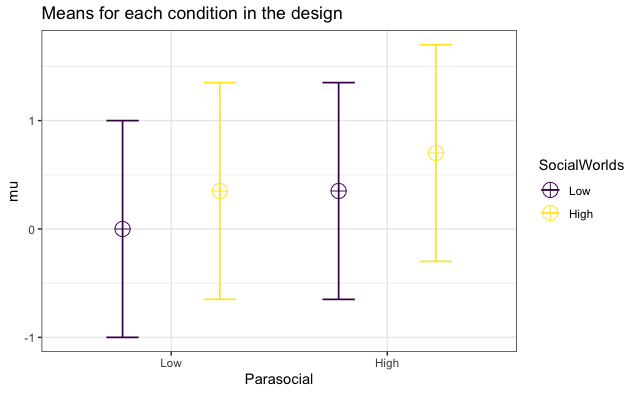

```r
study3_design_pattern2 <- ANOVA_design(design = "2b*2b",
                              n = 172 * 3,
                              mu = c(0,
                                     study3_target_d,
                                     study3_target_d,
                                     study3_target_d * 2), sd = 1,
                              labelnames = c("Parasocial", "Low", "High",
                                             "SocialWorlds", "Low", "High"),
                              plot = TRUE)
```

```
Achieved Power and Sample Size for ANOVA-level effects
```

| variable | label | n | achieved_power | desired_power |
| --- | --- | --- | --- | --- |
| Parasocial | Desired Power Achieved | 86 | 90 | 90 |
| SocialWorlds | Desired Power Achieved | 86 | 90 | 90 |
| Parasocial:SocialWorlds | Desired Power Not Reached | 100 | 5 | 90 |

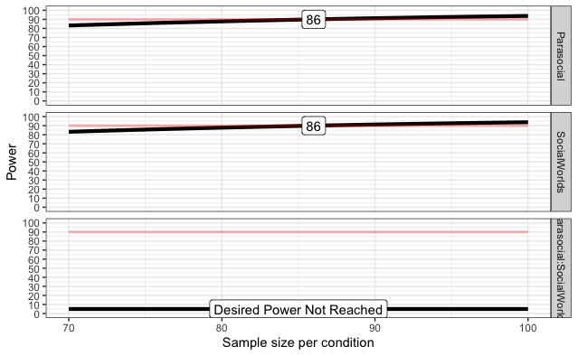

```r
study3_pattern2_results<- plot_power(study3_design_pattern2,
           min = 70,
           max = 100)
```

```r
ANOVA_exact(study3_design_pattern2, alpha_level = 0.05)
```

```
Power and Effect sizes for ANOVA tests
```

|  | power | partial_eta_squared | cohen_f | non_centrality |
| --- | --- | --- | --- | --- |
| Parasocial | 100 | 0.0299 | 0.1754 | 63.4101 |
| SocialWorlds | 100 | 0.0299 | 0.1754 | 63.4101 |
| Parasocial:SocialWorlds | 5 | 0.0000 | 0.0000 | 0.0000 |

```
Power and Effect sizes for pairwise comparisons (t-tests)
```

|  | power | effect_size |
| --- | --- | --- |
| p_Parasocial_Low_SocialWorlds_Low_Parasocial_Low_SocialWorlds_High | 99.99 | 0.35 |
| p_Parasocial_Low_SocialWorlds_Low_Parasocial_High_SocialWorlds_Low | 99.99 | 0.35 |
| p_Parasocial_Low_SocialWorlds_Low_Parasocial_High_SocialWorlds_High | 100.00 | 0.70 |
| p_Parasocial_Low_SocialWorlds_High_Parasocial_High_SocialWorlds_Low | 5.00 | 0.00 |
| p_Parasocial_Low_SocialWorlds_High_Parasocial_High_SocialWorlds_High | 99.99 | 0.35 |
| p_Parasocial_High_SocialWorlds_Low_Parasocial_High_SocialWorlds_High | 99.99 | 0.35 |

```
Power and Effect sizes for ANOVA tests
```

|  | power | partial_eta_squared | cohen_f | non_centrality |
| --- | --- | --- | --- | --- |
| Parasocial | 100 | 0.0299 | 0.1754 | 63.4101 |
| SocialWorlds | 100 | 0.0299 | 0.1754 | 63.4101 |
| Parasocial:SocialWorlds | 5 | 0.0000 | 0.0000 | 0.0000 |

```
Power and Effect sizes for pairwise comparisons (t-tests)
```

|  | power | effect_size |
| --- | --- | --- |
| p_Parasocial_Low_SocialWorlds_Low_Parasocial_Low_SocialWorlds_High | 99.99 | 0.35 |
| p_Parasocial_Low_SocialWorlds_Low_Parasocial_High_SocialWorlds_Low | 99.99 | 0.35 |
| p_Parasocial_Low_SocialWorlds_Low_Parasocial_High_SocialWorlds_High | 100.00 | 0.70 |
| p_Parasocial_Low_SocialWorlds_High_Parasocial_High_SocialWorlds_Low | 5.00 | 0.00 |
| p_Parasocial_Low_SocialWorlds_High_Parasocial_High_SocialWorlds_High | 99.99 | 0.35 |
| p_Parasocial_High_SocialWorlds_Low_Parasocial_High_SocialWorlds_High | 99.99 | 0.35 |

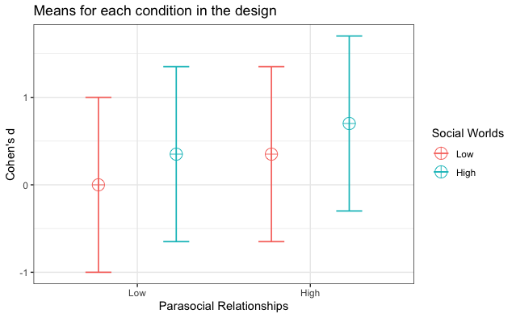

```r
study3_design_pattern2$meansplot +
  ylab("Cohen's d") +
  xlab("Parasocial Relationships") +
  scale_color_discrete(name = "Social Worlds")
```

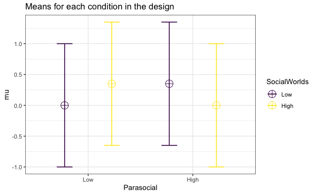

```r
study3_design_pattern3 <- ANOVA_design(design = "2b*2b",
                              n = 86,
                              mu = c(0,
                                     study3_target_d,
                                     study3_target_d,
                                     0), sd = 1,
                              labelnames = c("Parasocial", "Low", "High",
                                             "SocialWorlds", "Low", "High"),
                              plot = TRUE)
```

```r
ANOVA_exact(study3_design_pattern3, alpha_level = 0.05)
```

```
Power and Effect sizes for ANOVA tests
```

|  | power | partial_eta_squared | cohen_f | non_centrality |
| --- | --- | --- | --- | --- |
| Parasocial | 5.0000 | 0.0000 | 0.0000 | 0.0000 |
| SocialWorlds | 5.0000 | 0.0000 | 0.0000 | 0.0000 |
| Parasocial:SocialWorlds | 90.0033 | 0.0301 | 0.1763 | 10.5684 |

```
Power and Effect sizes for pairwise comparisons (t-tests)
```

|  | power | effect_size |
| --- | --- | --- |
| p_Parasocial_Low_SocialWorlds_Low_Parasocial_Low_SocialWorlds_High | 62.77 | 0.35 |
| p_Parasocial_Low_SocialWorlds_Low_Parasocial_High_SocialWorlds_Low | 62.77 | 0.35 |
| p_Parasocial_Low_SocialWorlds_Low_Parasocial_High_SocialWorlds_High | 5.00 | 0.00 |
| p_Parasocial_Low_SocialWorlds_High_Parasocial_High_SocialWorlds_Low | 5.00 | 0.00 |
| p_Parasocial_Low_SocialWorlds_High_Parasocial_High_SocialWorlds_High | 62.77 | -0.35 |
| p_Parasocial_High_SocialWorlds_Low_Parasocial_High_SocialWorlds_High | 62.77 | -0.35 |

```
Power and Effect sizes for ANOVA tests
```

|  | power | partial_eta_squared | cohen_f | non_centrality |
| --- | --- | --- | --- | --- |
| Parasocial | 5.0000 | 0.0000 | 0.0000 | 0.0000 |
| SocialWorlds | 5.0000 | 0.0000 | 0.0000 | 0.0000 |
| Parasocial:SocialWorlds | 90.0033 | 0.0301 | 0.1763 | 10.5684 |

```
Power and Effect sizes for pairwise comparisons (t-tests)
```

|  | power | effect_size |
| --- | --- | --- |
| p_Parasocial_Low_SocialWorlds_Low_Parasocial_Low_SocialWorlds_High | 62.77 | 0.35 |
| p_Parasocial_Low_SocialWorlds_Low_Parasocial_High_SocialWorlds_Low | 62.77 | 0.35 |
| p_Parasocial_Low_SocialWorlds_Low_Parasocial_High_SocialWorlds_High | 5.00 | 0.00 |
| p_Parasocial_Low_SocialWorlds_High_Parasocial_High_SocialWorlds_Low | 5.00 | 0.00 |
| p_Parasocial_Low_SocialWorlds_High_Parasocial_High_SocialWorlds_High | 62.77 | -0.35 |
| p_Parasocial_High_SocialWorlds_Low_Parasocial_High_SocialWorlds_High | 62.77 | -0.35 |